# PREDICTIVE DISEASE MACHINE LEARNING MODEL FOR EFFECTIVE HEALTH INSURANCE MANAGEMENT

Arturo Chavez

2024-06-23

# 1 Background 📚

Research studies such as those conducted by [Lewis & Ellis, LLC](https://lewisellis.com/) and [The Society of Actuaries](https://www.soa.org/globalassets/assets/files/resources/research-report/2019/considerations-predictive-modeling.pdf) underscore the critical need for advanced predictive models within health insurance companies. These models are crucial for more accurately aligning insurance costs with individual health risks. By employing predictive modeling, insurers can better address the discrepancies between the costs individuals pay and the services they receive. This not only aids in accurate risk prediction to prevent coverage disparities but also enhances financial planning capabilities for insurance providers, ultimately leading to more equitable health coverage.

The advantages of this approach include the optimization of premium rates, more effective risk management, and the ability to make well-informed decisions about policyholder engagement and fraud prevention. Furthermore, this strategy not only aids in identifying high-risk individuals but also boosts customer satisfaction by customizing insurance products to meet specific needs.

# 2 Objectives 🎯

**Predict** the likelihood of new patients developing a certain disease, based on their health features.

**Identify** the primary risk determinants that significantly elevate the probability of diseases.

**Summary:** This approach allows for more targeted healthcare interventions and preventative measures, enhancing patient outcomes.

# 3 Key Concepts🔑

- Predictive Risk Modeling
- Efective Heatlh Insurance Management
- Fair Health Coverage
- Premium Rate Optimization
- Customer Satisfaction

# 4 Project Data Source 📁

The data for this project is derived from the [BRFSS 2019 survey](https://www.cdc.gov/brfss/annual_data/annual_2019.html), which gathers information on health-related risk behaviors among the U.S. population that have cancer.

**Important Note 🎯** The dataset used here exemplifies how we can predict specific diseases based on survey data.This project’s methodology is designed with flexibility in mind, allowing for easy adaptation to other health surveys sharing similar features. With only minor modifications, tailored to specific domain knowledge, this framework can be applied by data specialists at health insurance companies to suit a variety of analytical needs. This adaptability ensures that specialists can leverage this approach to analyze data pertinent to their specific requirements, enhancing the project’s utility across different health-related datasets.

# 5 Methodology📊

[output not shown]

# 6 Data Insights 🔍

| Variable | Description | Variable | Description | Variable | Description |
| --- | --- | --- | --- | --- | --- |
| **FMONTH** | Month when the interview was completed | **PERSDOC2** | Primary doctor status | **DIABETE4** | Diabetes status |
| **IDATE** | Interview date | **MEDCOST** | Medical costs not seen due to expense | **HAVARTH4** | Arthritis status |
| **IMONTH** | Interview month | **CHECKUP1** | Time since last routine checkup | **MARITAL** | Marital status |
| **IDAY** | Interview day | **BPHIGH4** | High blood pressure | **EDUCA** | Education level |
| **IYEAR** | Interview year | **CHOLCHK2** | Cholesterol checked | **RENTHOM1** | Home ownership |
| **DISPCODE** | Disposition code | **TOLDHI2** | Told have high cholesterol | **CPDEMO1B** | Telephone usage |
| **SEQNO** | Unique sequence number | **CVDINFR4** | Ever told had heart attack | **VETERAN3** | Veteran status |
| **SEXVAR** | Respondent sex | **CVDCRHD4** | Ever told had angina or coronary heart disease | **EMPLOY1** | Employment status |
| **GENHLTH** | General health status | **CVDSTRK3** | Ever told had stroke | **CHILDREN** | Number of children |
| **PHYSHLTH** | Physical health status days | **ASTHMA3** | Asthma status | **INCOME2** | Income levels |
| **MENTHLTH** | Mental health status days | **CHCCOPD2** | Chronic obstructive pulmonary disease status | **WEIGHT2** | Weight in pounds |
| **HLTHPLN1** | Health care coverage | **ADDEPEV3** | Ever diagnosed with depression | **HEIGHT3** | Height in inches |
| **DEAF** | Hearing difficulty | **DIFFDRES** | Dressing difficulty | **FRENCHF1** | French fries or chips consumption |
| **BLIND** | Vision difficulty | **DIFFALON** | Living alone difficulty | **POTATOE1** | Potatoes consumption |
| **DECIDE** | Decision making difficulty | **SMOKE100** | Smoking status | **VEGETAB2** | Vegetables consumption |
| **DIFFWALK** | Walking difficulty | **USENOW3** | Tobacco use | **FLUSHOT7** | Flu shot status |
| **CHCKDNY2** | Chronic kidney disease | **ALCDAY5** | Alcohol consumption days | **TETANUS1** | Tetanus shot status |
| **EXERANY2** | Exercise status | **STRENGTH** | Strength training frequency | **PNEUVAC4** | Pneumonia vaccine status |
| **FRUIT2** | Fruit consumption frequency | **FRUITJU2** | Fruit juice consumption | **HIVTST7** | HIV test status |
| **FVGREEN1** | Vegetable consumption frequency | **HIVRISK5** | HIV risk assessment | **QSTVER** | Questionnaire version |
| **HTIN4** | Height in inches (rounded) | **HTM4** | Height in meters | **WTKG3** | Weight in kilograms |
| **DRNKANY5** | Any drinking status | **Class** | Patient Cancer Status |  |  |

# 7 Data Pre-processing 🧹

## 7.1 Data Dimension Reduction 📉

### 7.1.1 Columns that will not be useful for analysis based on domain knowledge 🚮

Columns related to the administration of the interview are removed because they do not provide predictive value and may introduce noise into the model.

**Columns**: `FMONTH`, `IDATE`, `IMONTH`, `IDAY`, `IYEAR`, `DISPCODE`, `SEQNO, MARITAL, EDUCA, RENTHOM1, CPDEMO1B, EMPLOY1, INCOME2, QSTVER, QSTLANG, HTIN4, WEIGHT2, HEIGHT3`

```r
df <- df %>%
  select(-FMONTH, -IDATE, -IMONTH, -IDAY, -IYEAR, -SEQNO, -DISPCODE,
         -CPDEMO1B, -MARITAL, -EDUCA, -RENTHOM1, -EMPLOY1, -INCOME2,
         -QSTVER, -QSTLANG, -HTIN4, -WEIGHT2, -HEIGHT3)
df <- df %>%
  select(-all_of(nearZeroVar(df, names = TRUE)))
numeric_cols <- df %>% select(where(is.numeric))
highly.correlated.variables <- findCorrelation(cor(numeric_cols, use = "complete.obs"), cutoff = 0.7, names = TRUE)
df <- df %>% select(-all_of(highly.correlated.variables))
```

### 7.1.2 Columns with almost 0 variance 🚮

Columns with almost zero variance are removed because they provide no useful information for distinguishing between data points and do not contribute to model prediction accuracy.

**Columns**: `CHCKDNY`, `DIFFDRES`, `USENOW3`, `HIVRISK5`

```r
df <- df %>%
  select(-all_of(nearZeroVar(df, names = TRUE)))
```

### 7.1.3 Columns with correlation 🚮

Columns with high correlation are often removed to prevent multicollinearity, which can distort the estimated coefficients and reduce model interpretability.

**Columns**: `ALCDAY5`

```r
numeric_cols <- df %>% select(where(is.numeric))
highly.correlated.variables <- findCorrelation(cor(numeric_cols, use = "complete.obs"), cutoff = 0.7, names = TRUE)
df <- df %>% select(-all_of(highly.correlated.variables))
```

### 7.1.4 Multiple Correspondence Analysis 🚮

Multiple Correspondence Analysis (MCA) is used to reduce dimensionality and uncover underlying patterns in categorical data, enhancing model simplicity and effectiveness.

```r
df_factors <- df %>% mutate_if(is.numeric, as.factor)

# Perform MCA
mca_results <- MCA(df_factors, graph = FALSE)

# Get the contributions of variables to the first two dimensions
contrib_dim1 <- mca_results$var$contrib[,1]
contrib_dim2 <- mca_results$var$contrib[,2]

# Combine contributions and identify the top contributing variables
contrib_total <- contrib_dim1 + contrib_dim2
top_vars <- names(sort(contrib_total, decreasing = TRUE)[1:40])  # Top 10 variables, adjust as needed
strip_suffix <- function(var_names) {
  # Remove everything after and including the first underscore
  original_names <- gsub("(_|\\.).*$", "", var_names)
  return(original_names)
}

# Apply the function to top_vars
original_vars <- strip_suffix(top_vars)
# Get unique original variable names
unique_original_vars <- unique(original_vars)
# Filter the dataframe to keep only the top contributing variables
df_principal_vars <- df_factors %>% select(all_of(unique_original_vars))
# Filter the dataframe to keep only the top contributing variables
df <- df_factors %>%
  select(Class, all_of(unique_original_vars))
```

The four graphs, representing the columns with the highest variance after performing MCA, illustrate the dominant dimensions of variability, highlighting key categorical relationships and differences within the dataset.

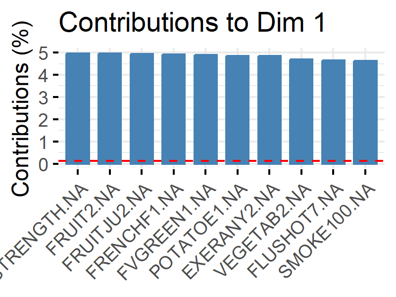

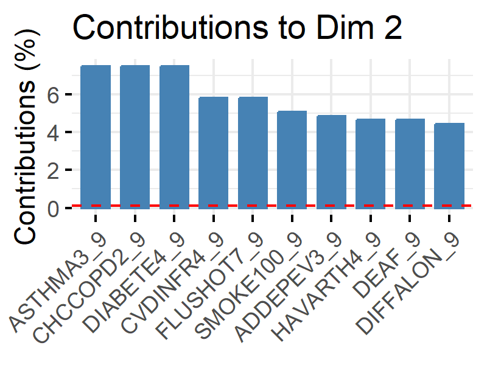

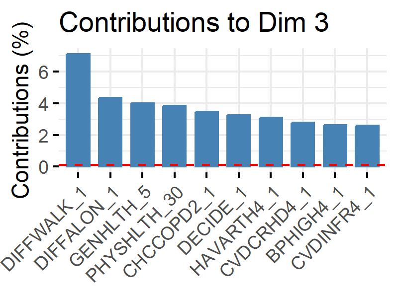

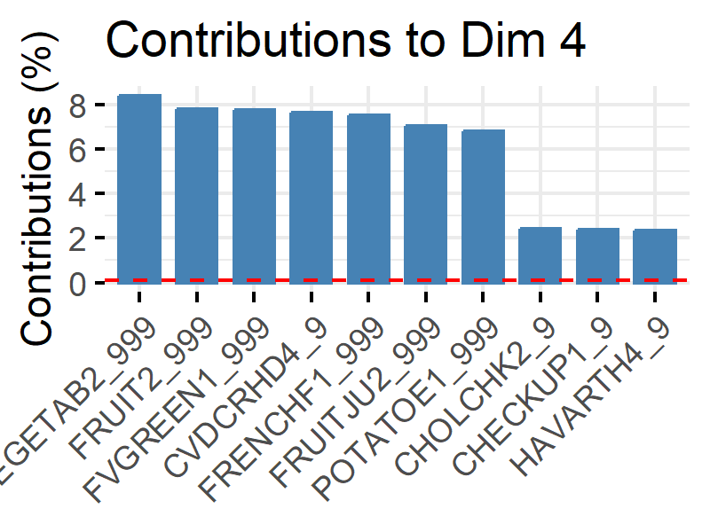

## 7.2 Data Normalization 📕

For normalization, recodification based on domain knowledge is essential; values like “Don’t know/Not sure,” “Refused,” and other nonsensical responses are recoded as NA to ensure data quality and consistency, enabling more accurate analysis and comparisons across different variables.

```r
scale <- function(x) {
  (x - min(x, na.rm = TRUE)) / (max(x, na.rm = TRUE) - min(x, na.rm = TRUE))
}
df[] <- lapply(names(df), function(column_name) {
  # Access the column by its name
  x <- df[[column_name]]

  # Check if the column is not 'Class', is a factor, and needs conversion
  if (column_name != "Class" && is.factor(x)) {
    # Convert factor to numeric by first converting to character
    as.numeric(as.character(x))
  } else {
    # Leave the column as is if it's 'Class', numeric or should not be converted
    x
  }
})
#MENTHLTH
df$MENTHLTH[!(df$MENTHLTH  %in% c(1:30))] <- NA
df$MENTHLTH <- scale(df$MENTHLTH)


#CHOLCHK2
df$CHOLCHK2[!(df$CHOLCHK2 %in% c(1,2,3,4,5,6))] <- NA
df$CHOLCHK2<- scale(df$CHOLCHK2)

#CVDINFR4
df$CVDINFR4[!(df$CVDINFR4 %in% c(1,2))] <- NA
df$CVDINFR4<- scale(df$CVDINFR4)

#CVDCRHD4
df$CVDCRHD4[!(df$CVDCRHD4 %in% c(1,2))] <- NA
df$CVDCRHD4<- scale(df$CVDCRHD4)

#ASTHMA3
df$ASTHMA3[!(df$ASTHMA3 %in% c(1,2))] <- NA
df$ASTHMA3 <- scale(df$ASTHMA3)

#CHCCOPD2
df$CHCCOPD2[!(df$CHCCOPD2 %in% c(1,2))] <- NA
df$CHCCOPD2<- scale(df$CHCCOPD2)

#ADDEPEV3
df$ADDEPEV3[!(df$ADDEPEV3 %in% c(1,2))] <- NA
df$ADDEPEV3 <- scale(df$ADDEPEV3)

#HAVARTH4
df$HAVARTH4[!(df$HAVARTH4 %in% c(1,2))] <- NA
df$HAVARTH4<- scale(df$DIABETE4)

#VETERAN3
df$VETERAN3[!(df$VETERAN3 %in% c(1,2))] <- NA
df$VETERAN3<- scale(df$VETERAN3)

#DEAF
df$DEAF[!(df$DEAF %in% c(1,2))] <- NA
df$DEAF<- scale(df$DEAF)

#BLIND
df$BLIND[!(df$BLIND %in% c(1,2))] <- NA
df$BLIND<- scale(df$BLIND)

#DECIDE
df$DECIDE[!(df$DECIDE %in% c(1,2))] <- NA
df$DECIDE <- scale(df$DECIDE)

#DIFFWALK
df$DIFFWALK[!(df$DIFFWALK %in% c(1,2))] <- NA
df$DIFFWALK <- scale(df$DIFFWALK)

#DIFFALON
df$DIFFALON[!(df$DIFFALON %in% c(1,2))] <- NA
df$DIFFALON<- scale(df$DIFFALON)

#SMOKE100
df$SMOKE100[!(df$SMOKE100 %in% c(1,2))] <- NA
df$SMOKE100<- scale(df$SMOKE100)

#EXERANY2
df$EXERANY2[!(df$EXERANY2 %in% c(1,2))] <- NA
df$EXERANY2<- scale(df$EXERANY2)

#FLUSHOT7
df$FLUSHOT7[!(df$FLUSHOT7 %in% c(1,2))] <- NA
df$FLUSHOT7 <- scale(df$FLUSHOT7)

#PNEUVAC4
df$PNEUVAC4[!(df$PNEUVAC4 %in% c(1,2))] <- NA
df$PNEUVAC4 <- scale(df$PNEUVAC4)

#HIVTST7
df$HIVTST7[!(df$HIVTST7 %in% c(1,2))] <- NA
df$HIVTST7 <- scale(df$HIVTST7)

#DRNKANY5
df$DRNKANY5[!(df$DRNKANY5 %in% c(1,2))] <- NA
df$DRNKANY5 <- scale(df$DRNKANY5)

#TETANUS1
df$TETANUS1[(df$TETANUS1 %in% c(7,9))] <- NA
df$TETANUS1 <- scale(df$TETANUS1)

#DIABETE4
df$DIABETE4 <- ifelse(!(df$DIABETE4 %in% c(1, 2, 3, 4)), NA, df$DIABETE4)
df$DIABETE4 <- recode(df$DIABETE4, `1` = 8, `2` = 7, `3` = 5, `4` = 6)
df$DIABETE4 <- scale(df$DIABETE4)

#STRENGTH
df$STRENGTH[df$STRENGTH %in% c(200, 777, 999)] <- NA
df$STRENGTH[df$STRENGTH == 888] <- 0
df$STRENGTH <- ifelse(df$STRENGTH %in% 101:199, df$STRENGTH %% 100, df$STRENGTH)
df$STRENGTH <- ifelse(df$STRENGTH %in% 201:299, df$STRENGTH %% 200, df$STRENGTH)
df$STRENGTH <- round(scale(df$STRENGTH),1)

#FRUIT2
df$FRUIT2[df$FRUIT2 %in% c(777, 999, 555, 300)] <- NA
df$FRUIT2[df$FRUIT2 %in% c(555, 300)] <- c(0, 0.5)[match(df$FRUIT2, c(555, 300))]
df$FRUIT2 <- ifelse(df$FRUIT2 %in% 101:199, df$FRUIT2 %% 100, df$FRUIT2)
df$FRUIT2 <- ifelse(df$FRUIT2 %in% 201:299, df$FRUIT2 %% 200, df$FRUIT2)
df$FRUIT2 <- ifelse(df$FRUIT2 %in% 301:399, df$FRUIT2 %% 300, df$FRUIT2)
df$FRUIT2 <- round(scale(df$FRUIT2),2)

#FRUITJU2
df$FRUITJU2[df$FRUITJU2 %in% c(777, 999)] <- NA
df$FRUITJU2[df$FRUITJU2 %in% c(555, 300)] <- 0
df$FRUITJU2 <- ifelse(df$FRUITJU2 %in% 101:199, df$FRUITJU2 %% 100, df$FRUITJU2)
df$FRUITJU2 <- ifelse(df$FRUITJU2 %in% 201:299, df$FRUITJU2 %% 200, df$FRUITJU2)
df$FRUITJU2 <- ifelse(df$FRUITJU2 %in% 301:399, df$FRUITJU2 %% 300, df$FRUITJU2)
df$FRUITJU2 <- round(scale(df$FRUITJU2),1)

#FVGREEN1
df$FVGREEN1[df$FVGREEN1 %in% c(777, 999)] <- NA
df$FVGREEN1[df$FVGREEN1 %in% c(555, 300)] <- 0
df$FVGREEN1 <- ifelse(df$FVGREEN1 %in% 101:199, df$FVGREEN1 %% 100 , df$FVGREEN1)
df$FVGREEN1 <- ifelse(df$FVGREEN1 %in% 201:299, df$FVGREEN1 %% 200 , df$FVGREEN1)
df$FVGREEN1 <- ifelse(df$FVGREEN1 %in% 301:399, df$FVGREEN1 %% 300, df$FVGREEN1)
df$FVGREEN1 <- round(scale(df$FVGREEN1),1)

#FRENCHF1
df$FRENCHF1[df$FRENCHF1 %in% c(777, 999, 200)] <- NA
df$FRENCHF1[df$FRENCHF1 %in% c(555, 300)] <- 0
df$FRENCHF1 <- ifelse(df$FRENCHF1 %in% 101:199, df$FRENCHF1 %% 100, df$FRENCHF1)
df$FRENCHF1 <- ifelse(df$FRENCHF1 %in% 201:299, df$FRENCHF1 %% 200, df$FRENCHF1)
df$FRENCHF1 <- ifelse(df$FRENCHF1 %in% 301:399, df$FRENCHF1 %% 300, df$FRENCHF1)
df$FRENCHF1 <- round(scale(df$FRENCHF1),1)

#POTATOE1
df$POTATOE1[df$POTATOE1 %in% c(777, 999)] <- NA
df$POTATOE1[df$POTATOE1 %in% c(555, 300)] <- 0
df$POTATOE1 <- ifelse(df$POTATOE1 %in% 101:199, df$POTATOE1 %% 100, df$POTATOE1)
df$POTATOE1 <- ifelse(df$POTATOE1 %in% 201:299, df$POTATOE1 %% 200, df$POTATOE1)
df$POTATOE1 <- ifelse(df$POTATOE1 %in% 301:399, df$POTATOE1 %% 300, df$POTATOE1)
df$POTATOE1 <- round(scale(df$POTATOE1),1)

#VEGETAB2
df$VEGETAB2[df$VEGETAB2 %in% c(777, 999)] <- NA
df$VEGETAB2[df$VEGETAB2 %in% c(555, 300)] <- 0
df$VEGETAB2 <- ifelse(df$VEGETAB2 %in% 101:199, df$VEGETAB2 %% 100, df$VEGETAB2)
df$VEGETAB2 <- ifelse(df$VEGETAB2 %in% 201:299, df$VEGETAB2 %% 200, df$VEGETAB2)
df$VEGETAB2 <- ifelse(df$VEGETAB2 %in% 301:399, df$VEGETAB2 %% 300, df$VEGETAB2)
df$VEGETAB2 <- round(scale(df$VEGETAB2),1)

#####The code builds a **decision tree** to predict Class using HTM4, extracts split points using **entrophy**. If no splits are found, uses the 33rd and 66th percentiles of  bins HTM4 into categories based on these splits
#HTM4
tree_model <- rpart(Class ~ HTM4, data = df, method = "class", control=rpart.control(minsplit=1, cp=0.001))
splits <- sort(unique(tree_model$frame$split[!is.na(tree_model$frame$split)]))
if (length(splits) == 0) {
  splits <- quantile(df$HTM4, probs = c(0.33, 0.66), na.rm = TRUE)
}
labels <- as.character(1:(length(splits) + 1))
df$HTM4 <- cut(df$HTM4, breaks = c(-Inf, splits, Inf), include.lowest = TRUE, labels = labels)
df$HTM4 <- as.numeric(df$HTM4)
df$HTM4 <- scale(df$HTM4)
```

## 7.3 Filling Missing Values 🤷

We automate missing value imputation in a dataframe using linear regression models that leverage strong variable correlations to maintain data integrity and enhance analysis accuracy.

| Step | Description |
| --- | --- |
| 1 | **Compute Correlation Matrix**: Calculate the correlation matrix only from complete observations. |
| 2 | **Convert Correlation to Dataframe**: Transform the correlation matrix to a dataframe for ease of manipulation. |
| 3 | **Identify Columns with NAs**: Detect all columns that contain missing values. |
| 4 | **Find Highest Correlated Columns**: For each column with missing values, identify the column that has the highest correlation with it. |
| 5 | **Build Regression Models**: Construct a regression model for each pair of highly correlated columns. |
| 6 | **Predict Missing Values**: Use the regression models to estimate and fill in the missing values. |

### Implementation Details

- The correlation matrix is computed using only those rows that do not contain any missing values to ensure accuracy in correlation calculation.
- Each column’s strongest correlation is determined by absolute value, meaning both strong positive and negative correlations are considered.
- Regression models are built individually for each column with missing data based on its most correlated counterpart, providing tailored imputation.
- Predictions from these models directly replace the missing values, thus maintaining the integrity and distribution of the original data.

### Correlation heatmap

This graph, a correlation heatmap, visually represents the strength and direction of relationships between variables in a dataset, using color intensity to indicate the degree of correlation.

[figure not shown]

```r
# 1

fill_missing_with_regression <- function(df) { numeric_cols <- df %>% select(where(is.numeric))
correlation_matrix <- cor(numeric_cols, use = "complete.obs") # 1

# 2
correlation_df <- as.data.frame(correlation_matrix) %>%
  rownames_to_column(var = "Row") %>%
  pivot_longer(cols = -Row, names_to = "Column", values_to = "Correlation") %>%
  filter(Row != Column, !is.na(Correlation)) %>%
  arrange(desc(abs(Correlation)))

# 3
cols_with_na <- names(df)[colSums(is.na(df)) > 0]
print(paste("Columns with NA:", toString(cols_with_na)))

for (col in cols_with_na) {
  top_correlation <- correlation_df %>%
    filter(Row == col | Column == col) %>%
    slice_max(abs(Correlation), n = 1)
  # 4
  if (nrow(top_correlation) > 0) {
    predictor_col <- ifelse(top_correlation$Row[1] == col, top_correlation$Column[1], top_correlation$Row[1])
    print(paste("Processing:", col, "using", predictor_col))
    missing_indices <- which(is.na(df[[col]]) & !is.na(df[[predictor_col]]))
    if (length(missing_indices) == 0) {
      print(paste("No valid data to impute for column:", col))
      next}
    # 5
    formula <- as.formula(paste(col, "~", predictor_col))
    model <- lm(formula, data = df, na.action = na.exclude) # 5

    # 6
    predictions <- predict(model, newdata = df[missing_indices, , drop = FALSE], type = "response")
    df[[col]][missing_indices] <- predictions
  } else {
    print(paste("No correlations found for column:", col))}}
return(df)}
df <- fill_missing_with_regression(df)
df[df < 0] <- 0

df <- df[rowSums(is.na(df)) <= 3, ]
```

## 7.4 Pre-processed Data Snapshot 👻

This table showcases five observations from the dataset, following the completion of the pre-processing steps. It serves as an example of how the data has been cleaned and structured, ready for further analysis or modeling.

|  | Class | ASTHMA3 | CHCCOPD2 | DIABETE4 | CVDINFR4 | FLUSHOT7 | SMOKE100 | STRENGTH | FRUIT2 | FRUITJU2 | FRENCHF1 | FVGREEN1 | ADDEPEV3 | POTATOE1 | EXERANY2 | VEGETAB2 | HAVARTH4 | DEAF | DIFFALON | PNEUVAC4 | DRNKANY5 | DIFFWALK | DECIDE | BLIND | HIVTST7 | TETANUS1 | CHOLCHK2 | HTM4 | MENTHLTH | … |
| --- | --- | --- | --- | --- | --- | --- | --- | --- | --- | --- | --- | --- | --- | --- | --- | --- | --- | --- | --- | --- | --- | --- | --- | --- | --- | --- | --- | --- | --- | --- |
| 1 | Y | 1 | 0 | 0 | 1 | 0 | 0 | 0 | 0 | 0.1 | 0 | 0.1 | 0 | 0 | 0 | 0 | 0.2 | 1 | 1 | 0 | 0 | 0 | 1 | 1 | 1 | 0.7 | 0.2 | 1 | 1 | … |
| 2 | N | 1 | 1 | 0 | 1 | 1 | 1 | 0.1 | 0 | 0 | 0 | 0.1 | 1 | 0 | 0 | 0 | 0.2 | 1 | 1 | 0.7 | 0 | 1 | 1 | 1 | 0.7 | 1 | 0.2 | 0.5 | 0.3 | … |
| 3 | N | 1 | 1 | 0 | 1 | 1 | 1 | 0.3 | 0 | 0 | 0.1 | 0 | 0 | 0.1 | 0 | 0 | 0.2 | 0 | 0 | 1 | 0 | 0 | 0 | 0 | 0 | 0.7 | 0.2 | 0 | 1 | … |
| 4 | N | 1 | 1 | 0 | 1 | 1 | 1 | 0 | 0 | 0.1 | 0 | 0 | 1 | 0 | 0 | 0.1 | 0.2 | 1 | 1 | 1 | 0 | 1 | 1 | 1 | 1 | 0.3 | 0.2 | 0.5 | 0.3 | … |
| 5 | N | 1 | 1 | 1 | 1 | 1 | 1 | 0 | 0 | 0 | 0.1 | 0.1 | 1 | 0.1 | 0 | 0 | 0 | 1 | 1 | 0 | 0 | 1 | 1 | 1 | 1 | 1 | 0.2 | 1 | 0.3 | … |

# 8 Feature Engineering

## 8.1 Create Balanced Dataset

To ensure the avoidance of data leakage, we carefully split our balanced dataset. Initially, the entire dataset is divided into separate sets for training and testing. We make sure that the same data points are not present in both sets, thereby preventing the model from having prior knowledge of the test data, which can lead to overfitting and unrealistic performance estimates.

## 8.2 Data Dimension Reduction Method 1: Information Gain🧩

Information Gain is a method used to identify and select the most relevant features in a dataset. By measuring how well a feature splits the data, it helps in reducing dimensionality and focusing on the variables that contribute the most to the model’s predictive power.

## 8.3 Data Dimension Reduction Method 2: Boruta🧩

“Boruta is an all relevant feature selection method, while most other are minimal optimal; this means it tries to find all features carrying information usable for prediction, rather than finding a possibly compact subset of features on which some classifier has a minimal error.”

## 8.4 Data Dimension Reduction Method 3: Recursive Feature Elimination 🧩

“RFE iteratively removes less important features, creating a subset that maximizes predictive accuracy. By leveraging a machine learning algorithm and an importance-ranking metric, RFE evaluates each feature’s impact on model performance.”

# 9 Model Development 🤖

## 9.1 AdaBoost Classifier 🧠

We use Information Gain to select the most informative features for the AdaBoost model. This enhances AdaBoost’s efficiency and accuracy by focusing on features that significantly reduce uncertainty, improving overall model performance

```r
library(dplyr)
library(knitr)

calculate_measures_per_class_with_averages <- function(cm) {
  results <- data.frame(
    Class = character(),
    TPR = numeric(),
    FPR = numeric(),
    Precision = numeric(),
    Recall = numeric(),
    F_measure = numeric(),
    MCC = numeric(),
    Kappa = numeric(),
    stringsAsFactors = FALSE
  )

  total = sum(cm)
  po = (cm[1,1] + cm[2,2]) / total
  pe = ((cm[1,1] + cm[1,2]) * (cm[1,1] + cm[2,1]) + (cm[2,1] + cm[2,2]) * (cm[1,2] + cm[2,2])) / total^2

  for (i in 1:2) {
    if (i == 1) {
      tp = cm[1, 1]
      fp = cm[2, 1]
      fn = cm[1, 2]
      tn = cm[2, 2]
      class_label = "Class 0"
    } else {
      tp = cm[2, 2]
      fp = cm[1, 2]
      fn = cm[2, 1]
      tn = cm[1, 1]
      class_label = "Class 1"
    }

    tpr = round(tp / (tp + fn), 1)
    fpr = round(fp / (fp + tn), 1)
    precision = round(tp / (tp + fp), 1)
    recall = round(tpr, 1)  # recall is the same as TPR
    f_measure = round(ifelse((precision + recall) == 0, 0, (2 * precision * recall) / (precision + recall)), 1)
    mcc = round(ifelse((sqrt((tp+fp) * (tp+fn) * (tn+fp) * (tn+fn))) == 0, 0,
                 (tp * tn - fp * fn) / sqrt((tp+fp) * (tp+fn) * (tn+fp) * (tn+fn))), 1)
    kappa = round((po - pe) / (1 - pe), 1)

    results <- rbind(results, data.frame(
      Class = class_label,
      TPR = tpr,
      FPR = fpr,
      Precision = precision,
      Recall = recall,
      F_measure = f_measure,
      MCC = mcc,
      Kappa = kappa
    ))
  }

  supports = rowSums(cm)
  total_support = sum(supports)
  weighted_avgs <- sapply(results[, -1], function(x) sum(x * supports) / total_support, simplify = FALSE)

  weighted_row <- c("Wt. Average", sapply(unlist(weighted_avgs), function(x) round(x, 1)))
  results <- rbind(results, setNames(as.list(weighted_row), names(results)))

  results <- na.omit(results) # Remove rows with NA values
  results <- arrange(results, desc(Class)) # Optional: Sort by Class in descending order

  # Use knitr::kable() to create a nicely formatted table
  kable(results, format = "html", caption = "Class Performance Metrics with Weighted Averages")
}
```

### 9.1.1 Model 1 - Data splitting method 1 - Information Gain - ADA

Class Performance Metrics with Weighted Averages

| Class | TPR | FPR | Precision | Recall | F_measure | MCC | Kappa |
| --- | --- | --- | --- | --- | --- | --- | --- |
| Wt. Average | 0.6 | 0.4 | 0.8 | 0.6 | 0.6 | 0.2 | 0.2 |
| Class 1 | 0.6 | 0.4 | 0.3 | 0.6 | 0.4 | 0.2 | 0.2 |
| Class 0 | 0.6 | 0.4 | 0.9 | 0.6 | 0.7 | 0.2 | 0.2 |

### 9.1.2 Model 2 - Data splitting method 1 - Boruta - ADA

Class Performance Metrics with Weighted Averages

| Class | TPR | FPR | Precision | Recall | F_measure | MCC | Kappa |
| --- | --- | --- | --- | --- | --- | --- | --- |
| Wt. Average | 0.7 | 0.5 | 0.6 | 0.7 | 0.6 | 0.2 | 0.2 |
| Class 1 | 0.3 | 0.1 | 0.6 | 0.3 | 0.4 | 0.2 | 0.2 |
| Class 0 | 0.9 | 0.7 | 0.6 | 0.9 | 0.7 | 0.2 | 0.2 |

### 9.1.3 Model 3 - Data splitting method 1 - RFE - ADA

Class Performance Metrics with Weighted Averages

| Class | TPR | FPR | Precision | Recall | F_measure | MCC | Kappa |
| --- | --- | --- | --- | --- | --- | --- | --- |
| Wt. Average | 0.7 | 0.5 | 0.6 | 0.7 | 0.6 | 0.2 | 0.2 |
| Class 1 | 0.3 | 0.1 | 0.6 | 0.3 | 0.4 | 0.2 | 0.2 |
| Class 0 | 0.9 | 0.7 | 0.6 | 0.9 | 0.7 | 0.2 | 0.2 |

### 9.1.4 Model 4 - Data splitting method 2 - Information Gain - ADA

Class Performance Metrics with Weighted Averages

| Class | TPR | FPR | Precision | Recall | F_measure | MCC | Kappa |
| --- | --- | --- | --- | --- | --- | --- | --- |
| Wt. Average | 0.6 | 0.5 | 0.6 | 0.6 | 0.5 | 0.2 | 0.1 |
| Class 1 | 0.2 | 0.1 | 0.6 | 0.2 | 0.3 | 0.2 | 0.1 |
| Class 0 | 0.9 | 0.8 | 0.6 | 0.9 | 0.7 | 0.2 | 0.1 |

### 9.1.5 Model 5 - Data splitting method 2 - Boruta - ADA

Class Performance Metrics with Weighted Averages

| Class | TPR | FPR | Precision | Recall | F_measure | MCC | Kappa |
| --- | --- | --- | --- | --- | --- | --- | --- |
| Wt. Average | 0.7 | 0.5 | 0.6 | 0.7 | 0.6 | 0.2 | 0.2 |
| Class 1 | 0.3 | 0.1 | 0.6 | 0.3 | 0.4 | 0.2 | 0.2 |
| Class 0 | 0.9 | 0.7 | 0.6 | 0.9 | 0.7 | 0.2 | 0.2 |

### 9.1.6 Model 6 - Data splitting method 2 - RFE - ADA

Class Performance Metrics with Weighted Averages

| Class | TPR | FPR | Precision | Recall | F_measure | MCC | Kappa |
| --- | --- | --- | --- | --- | --- | --- | --- |
| Wt. Average | 0.8 | 0.4 | 1 | 0.8 | 0.9 | 0.1 | 0.1 |
| Class 1 | 0.6 | 0.2 | 0.1 | 0.6 | 0.2 | 0.1 | 0.1 |
| Class 0 | 0.8 | 0.4 | 1 | 0.8 | 0.9 | 0.1 | 0.1 |

## 9.2 Random Forest Classifier 🧪

### 9.2.1 Model 7 - Data splitting method 1 - Information Gain - Random Forest

Class Performance Metrics with Weighted Averages

| Class | TPR | FPR | Precision | Recall | F_measure | MCC | Kappa |
| --- | --- | --- | --- | --- | --- | --- | --- |
| Wt. Average | 0.8 | 0.7 | 1 | 0.8 | 0.9 | 0.1 | 0 |
| Class 1 | 0.3 | 0.2 | 0 | 0.3 | 0 | 0.1 | 0 |
| Class 0 | 0.8 | 0.7 | 1 | 0.8 | 0.9 | 0.1 | 0 |

### 9.2.2 Model 8 - Data splitting method 1 - Boruta - Random Forest

Class Performance Metrics with Weighted Averages

| Class | TPR | FPR | Precision | Recall | F_measure | MCC | Kappa |
| --- | --- | --- | --- | --- | --- | --- | --- |
| Wt. Average | 0.8 | 1 | 1 | 0.8 | 0.9 | 0 | 0 |
| Class 1 | 0 | 0.2 | 0 | 0 | 0 | 0 | 0 |
| Class 0 | 0.8 | 1 | 1 | 0.8 | 0.9 | 0 | 0 |

### 9.2.3 Model 9 - Data splitting method 1 - RFE - Random Forest

Class Performance Metrics with Weighted Averages

| Class | TPR | FPR | Precision | Recall | F_measure | MCC | Kappa |
| --- | --- | --- | --- | --- | --- | --- | --- |
| Wt. Average | 0.8 | 0.6 | 1 | 0.8 | 0.9 | 0.1 | 0 |
| Class 1 | 0.4 | 0.2 | 0 | 0.4 | 0 | 0.1 | 0 |
| Class 0 | 0.8 | 0.6 | 1 | 0.8 | 0.9 | 0.1 | 0 |

### 9.2.4 Model 10 - Data splitting method 2 - Information Gain - Random Forest

Class Performance Metrics with Weighted Averages

| Class | TPR | FPR | Precision | Recall | F_measure | MCC | Kappa |
| --- | --- | --- | --- | --- | --- | --- | --- |
| Wt. Average | 0.8 | 0.3 | 1 | 0.8 | 0.9 | 0.1 | 0 |
| Class 1 | 0.7 | 0.2 | 0 | 0.7 | 0 | 0.1 | 0 |
| Class 0 | 0.8 | 0.3 | 1 | 0.8 | 0.9 | 0.1 | 0 |

### 9.2.5 Model 11 - Data splitting method 2 - BORUTA - Random Forest

Class Performance Metrics with Weighted Averages

| Class | TPR | FPR | Precision | Recall | F_measure | MCC | Kappa |
| --- | --- | --- | --- | --- | --- | --- | --- |
| Wt. Average | 0.8 | 1 | 1 | 0.8 | 0.9 | 0 | 0 |
| Class 1 | 0 | 0.2 | 0 | 0 | 0 | 0 | 0 |
| Class 0 | 0.8 | 1 | 1 | 0.8 | 0.9 | 0 | 0 |

### 9.2.6 Model 12 - Data splitting method 2 - RFE - Random Forest

Class Performance Metrics with Weighted Averages

| Class | TPR | FPR | Precision | Recall | F_measure | MCC | Kappa |
| --- | --- | --- | --- | --- | --- | --- | --- |
| Wt. Average | 0.8 | 0.4 | 1 | 0.8 | 0.9 | 0.1 | 0.1 |
| Class 1 | 0.6 | 0.2 | 0.1 | 0.6 | 0.2 | 0.1 | 0.1 |
| Class 0 | 0.8 | 0.4 | 1 | 0.8 | 0.9 | 0.1 | 0.1 |

## 9.3 Generalized Linear Model 🎲

The Generalized Linear Model (GLM) extends linear regression to accommodate non-normal error distributions and diverse response types, such as binary or count data. It adapts to various scenarios using link functions, enhancing its versatility for modeling different outcomes.

### 9.3.1 Model 13 - Data splitting method 1 - Information Gain - GLM

Class Performance Metrics with Weighted Averages

| Class | TPR | FPR | Precision | Recall | F_measure | MCC | Kappa |
| --- | --- | --- | --- | --- | --- | --- | --- |
| Wt. Average | 0.8 | 0.7 | 1 | 0.8 | 0.9 | 0 | 0 |
| Class 1 | 0.3 | 0.2 | 0 | 0.3 | 0 | 0 | 0 |
| Class 0 | 0.8 | 0.7 | 1 | 0.8 | 0.9 | 0 | 0 |

### 9.3.2 Model 14 - Data splitting method 1 - BORUTA - GLM

Class Performance Metrics with Weighted Averages

| Class | TPR | FPR | Precision | Recall | F_measure | MCC | Kappa |
| --- | --- | --- | --- | --- | --- | --- | --- |
| Wt. Average | 0.8 | 0.6 | 1 | 0.8 | 0.9 | 0.1 | 0 |
| Class 1 | 0.4 | 0.2 | 0 | 0.4 | 0 | 0.1 | 0 |
| Class 0 | 0.8 | 0.6 | 1 | 0.8 | 0.9 | 0.1 | 0 |

### 9.3.3 Model 15 - Data splitting method 1 - RFE - GLM

Class Performance Metrics with Weighted Averages

| Class | TPR | FPR | Precision | Recall | F_measure | MCC | Kappa |
| --- | --- | --- | --- | --- | --- | --- | --- |
| Wt. Average | 0.8 | 0.5 | 1 | 0.8 | 0.9 | 0.1 | 0 |
| Class 1 | 0.5 | 0.2 | 0 | 0.5 | 0 | 0.1 | 0 |
| Class 0 | 0.8 | 0.5 | 1 | 0.8 | 0.9 | 0.1 | 0 |

### 9.3.4 Model 16 - Data splitting method 2 - Information Gain - GLM

Class Performance Metrics with Weighted Averages

| Class | TPR | FPR | Precision | Recall | F_measure | MCC | Kappa |
| --- | --- | --- | --- | --- | --- | --- | --- |
| Wt. Average | 0.8 | 0.4 | 1 | 0.8 | 0.9 | 0.1 | 0.1 |
| Class 1 | 0.6 | 0.2 | 0 | 0.6 | 0 | 0.1 | 0.1 |
| Class 0 | 0.8 | 0.4 | 1 | 0.8 | 0.9 | 0.1 | 0.1 |

### 9.3.5 Model 17 - Data splitting method 2 - Boruta - GLM

Class Performance Metrics with Weighted Averages

| Class | TPR | FPR | Precision | Recall | F_measure | MCC | Kappa |
| --- | --- | --- | --- | --- | --- | --- | --- |
| Wt. Average | 0.8 | 0.6 | 1 | 0.8 | 0.9 | 0.1 | 0.1 |
| Class 1 | 0.4 | 0.2 | 0.1 | 0.4 | 0.2 | 0.1 | 0.1 |
| Class 0 | 0.8 | 0.6 | 1 | 0.8 | 0.9 | 0.1 | 0.1 |

### 9.3.6 Model 18 - Data splitting method 2 - RFE - GLM

Class Performance Metrics with Weighted Averages

| Class | TPR | FPR | Precision | Recall | F_measure | MCC | Kappa |
| --- | --- | --- | --- | --- | --- | --- | --- |
| Wt. Average | 0.8 | 0.5 | 1 | 0.8 | 0.9 | 0.1 | 0 |
| Class 1 | 0.5 | 0.2 | 0 | 0.5 | 0 | 0.1 | 0 |
| Class 0 | 0.8 | 0.5 | 1 | 0.8 | 0.9 | 0.1 | 0 |

## 9.4 SVM Classifier 🔢

The SVM (Support Vector Machine) classifier identifies the optimal boundary between classes by maximizing the margin of separation in high-dimensional space. It excels in binary classification tasks and can handle nonlinear relationships using kernel functions.

### 9.4.1 Model 19 - Data splitting method 1 - INFORMATION GAIN - SVM

Class Performance Metrics with Weighted Averages

| Class | TPR | FPR | Precision | Recall | F_measure | MCC | Kappa |
| --- | --- | --- | --- | --- | --- | --- | --- |
| Wt. Average | 0.8 | 0.7 | 1 | 0.8 | 0.9 | 0.1 | 0 |
| Class 1 | 0.3 | 0.2 | 0 | 0.3 | 0 | 0.1 | 0 |
| Class 0 | 0.8 | 0.7 | 1 | 0.8 | 0.9 | 0.1 | 0 |

### 9.4.2 Model 20 - Data splitting method 1 - BOR - SVM

Class Performance Metrics with Weighted Averages

| Class | TPR | FPR | Precision | Recall | F_measure | MCC | Kappa |
| --- | --- | --- | --- | --- | --- | --- | --- |
| Wt. Average | 0.8 | 0.6 | 1 | 0.8 | 0.9 | 0.1 | 0 |
| Class 1 | 0.4 | 0.2 | 0 | 0.4 | 0 | 0.1 | 0 |
| Class 0 | 0.8 | 0.6 | 1 | 0.8 | 0.9 | 0.1 | 0 |

### 9.4.3 Model 21 - Data splitting method 1 - RFE - SVM

Class Performance Metrics with Weighted Averages

| Class | TPR | FPR | Precision | Recall | F_measure | MCC | Kappa |
| --- | --- | --- | --- | --- | --- | --- | --- |
| Wt. Average | 0.8 | 0.6 | 1 | 0.8 | 0.9 | 0.1 | 0 |
| Class 1 | 0.4 | 0.2 | 0 | 0.4 | 0 | 0.1 | 0 |
| Class 0 | 0.8 | 0.6 | 1 | 0.8 | 0.9 | 0.1 | 0 |

### 9.4.4 Model 22 - Data splitting method 2 - INFORMATION GAIN - SVM

Class Performance Metrics with Weighted Averages

| Class | TPR | FPR | Precision | Recall | F_measure | MCC | Kappa |
| --- | --- | --- | --- | --- | --- | --- | --- |
| Wt. Average | 0.8 | 0.8 | 0.7 | 0.8 | 0.7 | 0.1 | 0.1 |
| Class 1 | 0 | 0 | 0.5 | 0 | 0 | 0.1 | 0.1 |
| Class 0 | 1 | 1 | 0.8 | 1 | 0.9 | 0.1 | 0.1 |

### 9.4.5 Model 23 - Data splitting method 2 - BORUTA - SVM

Class Performance Metrics with Weighted Averages

| Class | TPR | FPR | Precision | Recall | F_measure | MCC | Kappa |
| --- | --- | --- | --- | --- | --- | --- | --- |
| Wt. Average | 0.8 | 0.8 | 0.7 | 0.8 | 0.7 | 0.1 | 0 |
| Class 1 | 0 | 0 | 0.4 | 0 | 0 | 0.1 | 0 |
| Class 0 | 1 | 1 | 0.8 | 1 | 0.9 | 0.1 | 0 |

### 9.4.6 Model 24 - Data splitting method 2 - RFE - SVM

Class Performance Metrics with Weighted Averages

| Class | TPR | FPR | Precision | Recall | F_measure | MCC | Kappa |
| --- | --- | --- | --- | --- | --- | --- | --- |
| Wt. Average | 0.8 | 0.8 | 0.8 | 0.8 | 0.7 | 0.1 | 0.1 |
| Class 1 | 0 | 0 | 0.6 | 0 | 0 | 0.1 | 0.1 |
| Class 0 | 1 | 1 | 0.8 | 1 | 0.9 | 0.1 | 0.1 |

## 9.5 Ctree Classifier 🔢

The ctree (Conditional Inference Tree) classifier constructs decision trees based on statistically significant associations. It uses permutation tests for independence between response and predictors to make unbiased splits, minimizing overfitting. This method provides a robust approach to modeling non-linear relationships and interactions among features.

### 9.5.1 Model 25 - Data splitting method 1 - INFORMATION GAIN - ctree

Class Performance Metrics with Weighted Averages

| Class | TPR | FPR | Precision | Recall | F_measure | MCC | Kappa |
| --- | --- | --- | --- | --- | --- | --- | --- |
| Wt. Average | 0.8 | 0.7 | 0.7 | 0.8 | 0.8 | 0.1 | 0.1 |
| Class 1 | 0.1 | 0 | 0.4 | 0.1 | 0.2 | 0.1 | 0.1 |
| Class 0 | 1 | 0.9 | 0.8 | 1 | 0.9 | 0.1 | 0.1 |

### 9.5.2 Model 26 - Data splitting method 1 - Boruta - ctree

Class Performance Metrics with Weighted Averages

| Class | TPR | FPR | Precision | Recall | F_measure | MCC | Kappa |
| --- | --- | --- | --- | --- | --- | --- | --- |
| Wt. Average | 0.8 | 0.8 | 0.7 | 0.8 | 0.7 | 0 | 0 |
| Class 1 | 0 | 0 | 0.3 | 0 | 0 | 0 | 0 |
| Class 0 | 1 | 1 | 0.8 | 1 | 0.9 | 0 | 0 |

### 9.5.3 Model 27 - Data splitting method 1 - RFE - ctree

Class Performance Metrics with Weighted Averages

| Class | TPR | FPR | Precision | Recall | F_measure | MCC | Kappa |
| --- | --- | --- | --- | --- | --- | --- | --- |
| Wt. Average | 0.8 | 0.8 | 0.7 | 0.8 | 0.7 | 0 | 0 |
| Class 1 | 0 | 0 | 0.3 | 0 | 0 | 0 | 0 |
| Class 0 | 1 | 1 | 0.8 | 1 | 0.9 | 0 | 0 |

### 9.5.4 Model 28 - Data splitting method 2 - INFORMATION GAIN - ctree

Class Performance Metrics with Weighted Averages

| Class | TPR | FPR | Precision | Recall | F_measure | MCC | Kappa |
| --- | --- | --- | --- | --- | --- | --- | --- |
| Wt. Average | 0.8 | 0.8 | 0.7 | 0.8 | 0.7 | 0.1 | 0 |
| Class 1 | 0 | 0 | 0.4 | 0 | 0 | 0.1 | 0 |
| Class 0 | 1 | 1 | 0.8 | 1 | 0.9 | 0.1 | 0 |

### 9.5.5 Model 29 - Data splitting method 2 - Boruta - ctree

Class Performance Metrics with Weighted Averages

| Class | TPR | FPR | Precision | Recall | F_measure | MCC | Kappa |
| --- | --- | --- | --- | --- | --- | --- | --- |
| Wt. Average | 0.8 | 0.7 | 0.7 | 0.8 | 0.8 | 0 | 0 |
| Class 1 | 0.1 | 0 | 0.3 | 0.1 | 0.1 | 0 | 0 |
| Class 0 | 1 | 0.9 | 0.8 | 1 | 0.9 | 0 | 0 |

### 9.5.6 Model 30 - Data splitting method 2 - RFE - ctree

Class Performance Metrics with Weighted Averages

| Class | TPR | FPR | Precision | Recall | F_measure | MCC | Kappa |
| --- | --- | --- | --- | --- | --- | --- | --- |
| Wt. Average | 0.8 | 0.8 | 0.7 | 0.8 | 0.7 | 0.1 | 0 |
| Class 1 | 0 | 0 | 0.5 | 0 | 0 | 0.1 | 0 |
| Class 0 | 1 | 1 | 0.8 | 1 | 0.9 | 0.1 | 0 |

## 9.6 GcvEarth Classifier 🔢

The gcvEarth classifier utilizes multivariate adaptive regression splines (MARS) to model complex nonlinear relationships in data. It employs generalized cross-validation (GCV) to optimize model complexity, focusing on essential interactions and trends for improved predictive accuracy. This approach allows it to handle varying data structures effectively.

### 9.6.1 Model 31 - Data splitting method 1 - INFORMATION GAIN - gcvEarth

Class Performance Metrics with Weighted Averages

| Class | TPR | FPR | Precision | Recall | F_measure | MCC | Kappa |
| --- | --- | --- | --- | --- | --- | --- | --- |
| Wt. Average | 0.8 | 0.7 | 1 | 0.8 | 0.9 | 0 | 0 |
| Class 1 | 0.3 | 0.2 | 0 | 0.3 | 0 | 0 | 0 |
| Class 0 | 0.8 | 0.7 | 1 | 0.8 | 0.9 | 0 | 0 |

### 9.6.2 Model 32 - Data splitting method 1 - BORUTA - gcvEarth

Class Performance Metrics with Weighted Averages

| Class | TPR | FPR | Precision | Recall | F_measure | MCC | Kappa |
| --- | --- | --- | --- | --- | --- | --- | --- |
| Wt. Average | 0.8 | 0.6 | 1 | 0.8 | 0.9 | 0.1 | 0.1 |
| Class 1 | 0.4 | 0.2 | 0.1 | 0.4 | 0.2 | 0.1 | 0.1 |
| Class 0 | 0.8 | 0.6 | 1 | 0.8 | 0.9 | 0.1 | 0.1 |

### 9.6.3 Model 33 - Data splitting method 1 - RFE - gcvEarth

Class Performance Metrics with Weighted Averages

| Class | TPR | FPR | Precision | Recall | F_measure | MCC | Kappa |
| --- | --- | --- | --- | --- | --- | --- | --- |
| Wt. Average | 0.8 | 0.6 | 1 | 0.8 | 0.9 | 0.1 | 0 |
| Class 1 | 0.4 | 0.2 | 0 | 0.4 | 0 | 0.1 | 0 |
| Class 0 | 0.8 | 0.6 | 1 | 0.8 | 0.9 | 0.1 | 0 |

### 9.6.4 Model 34 - Data splitting method 2 - INFORMATION GAIN - gcvEarth

Class Performance Metrics with Weighted Averages

| Class | TPR | FPR | Precision | Recall | F_measure | MCC | Kappa |
| --- | --- | --- | --- | --- | --- | --- | --- |
| Wt. Average | 0.8 | 0.6 | 1 | 0.8 | 0.9 | 0.1 | 0 |
| Class 1 | 0.4 | 0.2 | 0 | 0.4 | 0 | 0.1 | 0 |
| Class 0 | 0.8 | 0.6 | 1 | 0.8 | 0.9 | 0.1 | 0 |

### 9.6.5 Model 35 - Data splitting method 2 - BORUTA - gcvEarth

Class Performance Metrics with Weighted Averages

| Class | TPR | FPR | Precision | Recall | F_measure | MCC | Kappa |
| --- | --- | --- | --- | --- | --- | --- | --- |
| Wt. Average | 0.8 | 0.6 | 1 | 0.8 | 0.9 | 0.1 | 0 |
| Class 1 | 0.4 | 0.2 | 0 | 0.4 | 0 | 0.1 | 0 |
| Class 0 | 0.8 | 0.6 | 1 | 0.8 | 0.9 | 0.1 | 0 |

### 9.6.6 Model 36 - Data splitting method 2 - RFE - gcvEarth

Class Performance Metrics with Weighted Averages

| Class | TPR | FPR | Precision | Recall | F_measure | MCC | Kappa |
| --- | --- | --- | --- | --- | --- | --- | --- |
| Wt. Average | 0.8 | 0.5 | 1 | 0.8 | 0.9 | 0.1 | 0 |
| Class 1 | 0.5 | 0.2 | 0 | 0.5 | 0 | 0.1 | 0 |
| Class 0 | 0.8 | 0.5 | 1 | 0.8 | 0.9 | 0.1 | 0 |